# Reproducible Research: Peer Assessment 1

## Loading and preprocessing the data

```r
library(knitr)
library(dplyr)
setwd("~/R/R Projects/5.Reproducible Research/Peer Assessment 1")
alldata <- read.csv("activity.csv",header = T)
```

### Process/transform the data (if necessary) into a format suitable for your analysis

```r
data <- alldata[with (alldata, {
    !(is.na(steps))
}),]
```

## What is mean total number of steps taken per day?

### 1. Calculate the total number of steps taken per day

```r
steps_by_day <- summarise(group_by(data, date), total = sum(steps))
```

### 2. Make a histogram of the total number of steps taken each day

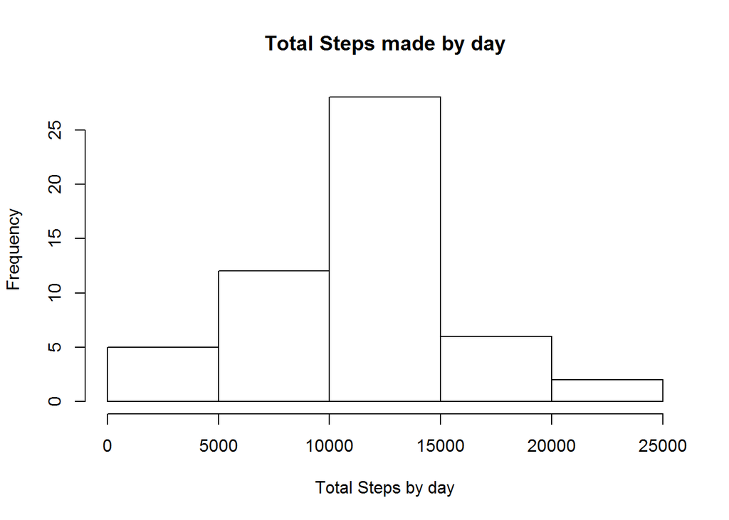

```r
hist(steps_by_day$total, main = "Total Steps made by day",xlab = "Total Steps by day")
```

### 3. Calculate and report the mean and median of the total number of steps taken per day

```r
summary(steps_by_day)
```

```
##          date        total
##  2012-10-02: 1   Min.   :   41
##  2012-10-03: 1   1st Qu.: 8841
##  2012-10-04: 1   Median :10765
##  2012-10-05: 1   Mean   :10766
##  2012-10-06: 1   3rd Qu.:13294
##  2012-10-07: 1   Max.   :21194
##  (Other)   :47
```

## What is the average daily activity pattern?

#### 1.Make a time series plot (i.e. type = “l”) of the 5-minute interval (x-axis) and the average number of steps taken, averaged across all days (y-axis)

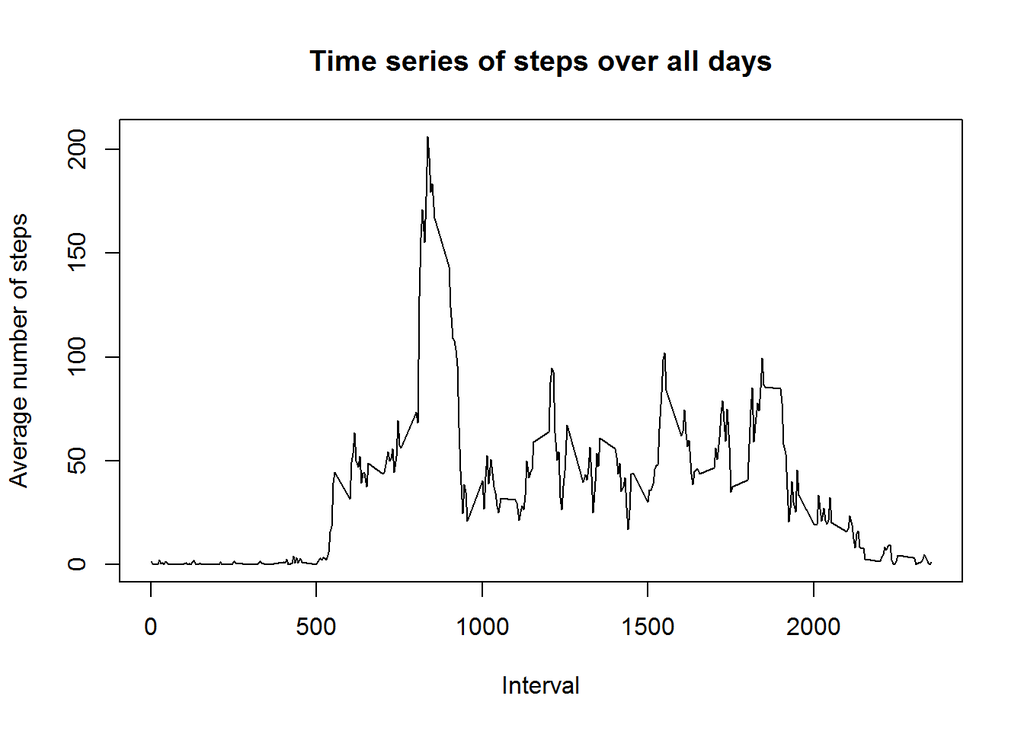

```r
steps_by_interval <- aggregate(steps ~ interval, data , mean)
plot(
    steps_by_interval$interval, steps_by_interval$steps, type = 'l',
    xlab = "Interval",
    ylab = "Average number of steps",main = "Time series of steps over all days"
)
```

#### 2. Which 5-minute interval, on average across all the days in the dataset, contains the maximum number of steps?

```r
max_steps_row <- which.max(steps_by_interval$steps)
steps_by_interval[max_steps_row,]
```

```
##     interval    steps
## 104      835 206.1698
```

## Imputing missing values

### 1. Calculate and report the total number of missing values in the dataset (i.e. the total number of rows with NAs)

```r
sum(is.na(alldata))
```

```
## [1] 2304
```

### 2. Devise a strategy for filling in all of the missing values in the dataset. The strategy does not need to be sophisticated. For example, you could use the mean/median for that day, or the mean for that 5-minute interval, etc

```r
newdata <- alldata
for (i in 1:nrow(newdata)) {
    if (is.na(newdata$steps[i])) {
        interval_value <- newdata$interval[i]
        steps_value <- steps_by_interval[steps_by_interval$interval == interval_value,]
        newdata$steps[i] <- steps_value$steps
    }
}
```

### 3. Create a new dataset that is equal to the original dataset but with the missing data filled in.

newdata is the new dataset

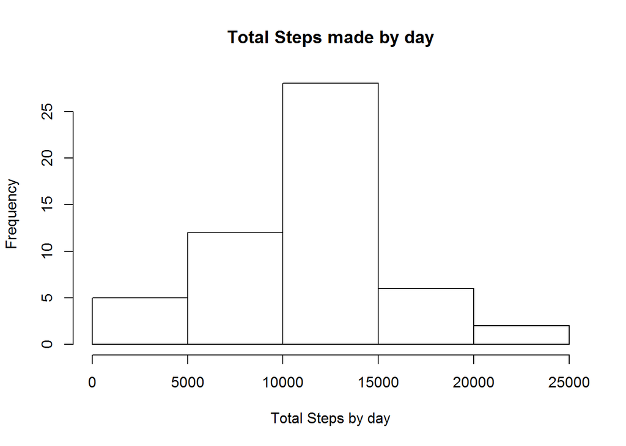

```r
new_steps_by_day <- aggregate(steps ~ date, data , sum)
hist(new_steps_by_day$steps, main="Total Steps made by day",
   xlab="Total Steps by day")
```

```r
mean(new_steps_by_day$steps)
```

```
## [1] 10766.19
```

```r
median(new_steps_by_day$steps)
```

```
## [1] 10765
```

```r
mean(steps_by_day$total)
```

```
## [1] 10766.19
```

```r
median(steps_by_day$total)
```

```
## [1] 10765
```

## Are there differences in activity patterns between weekdays and weekends?

### 1. Create a new factor variable in the dataset with two levels – “weekday” and “weekend” indicating whether a given date is a weekday or weekend day.

```r
Sys.setlocale("LC_TIME", "English")
```

```
## [1] "English_United States.1252"
```

```r
newdata['Day'] <- weekdays(as.Date(newdata$date))
newdata$Day[newdata$Day  %in% c('Saturday','Sunday') ] <- "weekend"
newdata$Day[!(newdata$Day=="weekend") ] <- "weekday"
newdata$Day <- as.factor(newdata$Day)
```

### 2. Make a panel plot containing a time series plot (i.e. type = “l”) of the 5-minute interval (x-axis) and the average number of steps taken, averaged across all weekday days or weekend days (y-axis). See the README file in the GitHub repository to see an example of what this plot should look like using simulated data.

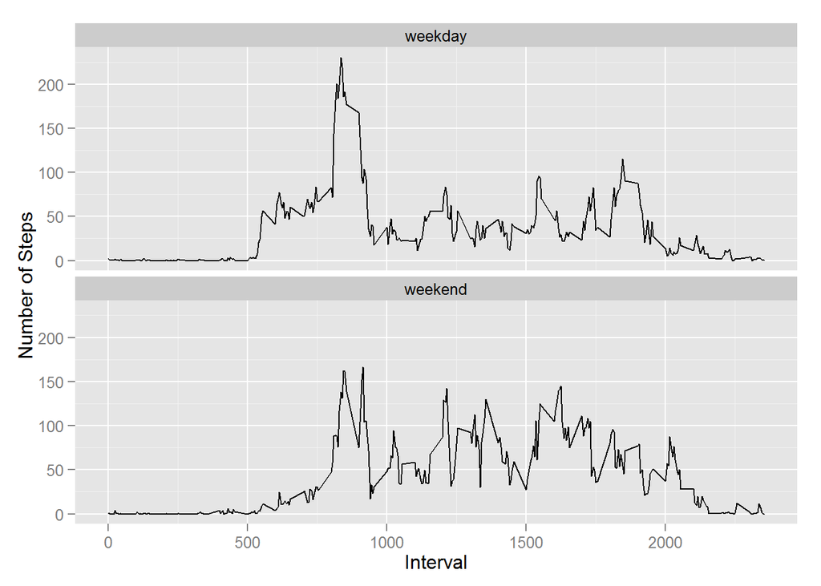

```r
new_steps_by_interval <- aggregate(steps ~ interval + Day, newdata, mean)

library(ggplot2)
qplot(interval, steps,data = new_steps_by_interval,
      geom=c("line"), type = 'l',xlab = "Interval",ylab = "Number of Steps") +
      facet_wrap(~ Day, ncol = 1)
```